# `WT` Control Series Equivalence

Two wild-type/`WT` variant datasets were collected, one as part of (i) the solvent-exchange experiment series, and (ii) for the mutant experiment series.

Our question can be phrased as:

> Are there systematic differences between these two `WT` control series that would prevent us pooling the data from the two series in any analysis?

Essentially, the question asks “can we ascribe a plausible non-zero difference in `WT` maximum amplitude or decay rate to the effect of a `Series`/batch parameter for the experiment, conditioned on `LPR` (which we anticipate affects both measurements)?”

Neither answer, yes or no, would prevent downstream statistical analysis, but it would inform how we use the control data.

The two `WT` datasets will always be reasonable controls for their corresponding experimental series, but if there is no effect ascribable to `Series`, we would have some justification for pooling the data. If there is a discernible effect due to `Series` we can incorporate `Series` as an explanatory variable and estimate its effect separately from that of the treatments we are interested in, should we require to pool the data.

## The Dataset

We process the `NeRh50_Table_S1_raw_data_used_in_figures.csv` dataset, to generate two dataframes - one describing maximum amplitude values, the other describing rate data, with a column indicating experimental series (Table 1).

```r
# Use helper script to load dataframes
source("assets/r/load_dataframes.R")
dfms <- load_dataframes()

# Show interactive tables of data
DT::datatable(dfms$dfm_wt_amp)
DT::datatable(dfms$dfm_wt_k)
# Write datasets to file (commented out for website)
#readr::write_csv(dfms$dfm_wt_amp, "assets/data/00_WT_controls_amplitude.csv")
#readr::write_csv(dfms$dfm_wt_k, "assets/data/00_WT_controls_rate.csv")
```

Table 1: Measurements for `WT` across two series. Values are measured at two values of `LPR`: `LPR5` and `LPR10`

(a) Maximum amplitude

|  | Series | Variant | Condition | LPR | Value |
| --- | --- | --- | --- | --- | --- |
| 1 | Series 1 | WT | H2O | LPR5 | 1.981 |
| 2 | Series 1 | WT | H2O | LPR5 | 1.686 |
| 3 | Series 1 | WT | H2O | LPR5 | 2.132 |
| 4 | Series 1 | WT | H2O | LPR5 | 1.988 |
| 5 | Series 1 | WT | H2O | LPR5 | 2.026 |
| 6 | Series 1 | WT | H2O | LPR5 | 1.99 |
| 7 | Series 1 | WT | H2O | LPR5 | 2.118 |
| 8 | Series 1 | WT | H2O | LPR5 | 2.194 |
| 9 | Series 1 | WT | H2O | LPR5 | 2.127 |
| 10 | Series 1 | WT | H2O | LPR10 | 1.114 |

[output cut: 19 more lines]

(b) Decay rate

|  | Series | Variant | Condition | LPR | Value |
| --- | --- | --- | --- | --- | --- |
| 1 | Series 1 | WT | H2O | LPR5 | 43.69 |
| 2 | Series 1 | WT | H2O | LPR5 | 44.83 |
| 3 | Series 1 | WT | H2O | LPR5 | 42.48 |
| 4 | Series 1 | WT | H2O | LPR5 | 42.58 |
| 5 | Series 1 | WT | H2O | LPR5 | 41.72 |
| 6 | Series 1 | WT | H2O | LPR5 | 49.97 |
| 7 | Series 1 | WT | H2O | LPR5 | 48.32 |
| 8 | Series 1 | WT | H2O | LPR5 | 42.44 |
| 9 | Series 1 | WT | H2O | LPR5 | 42.96 |
| 10 | Series 1 | WT | H2O | LPR10 | 36.13 |

[output cut: 19 more lines]

We visualise the distributions of datapoints between series, for each `LPR` value (Figure 1).

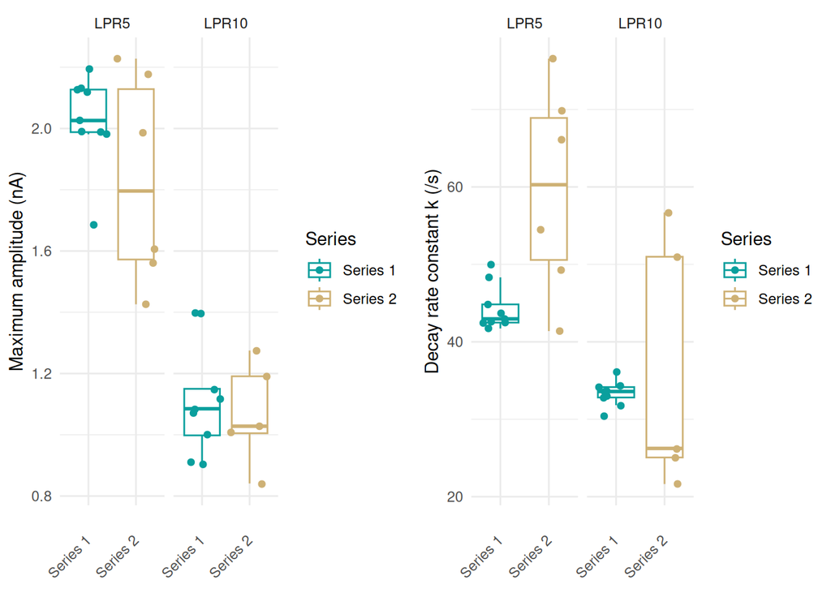

Figure 1: `WT` measurements across `LPR5` and `LPR10` for two batches/series

```r
p1_amp <- ggplot2::ggplot(dfms$dfm_wt_amp, ggplot2::aes(x=Series, y=Value, color=Series)) +
  ggplot2::geom_boxplot(outlier.shape = NA) +
  ggplot2::geom_jitter() +
  ggplot2::facet_wrap(~LPR) +
  ggplot2::labs(y="Maximum amplitude (nA)", x="") +
  ggplot2::theme_minimal() +
  ggplot2::theme(axis.text.x = ggplot2::element_text(angle = 45, vjust = 0.5, hjust=1))

# Visualise datasets as box/whisker with superimposed datapoints
p1_k <- ggplot2::ggplot(dfms$dfm_wt_k, ggplot2::aes(x=Series, y=Value, color=Series)) +
  ggplot2::geom_boxplot(outlier.shape = NA) +
  ggplot2::geom_jitter() +
  ggplot2::facet_wrap(~LPR) +
  ggplot2::labs(y="Decay rate constant k (/s)", x="") +
  ggplot2::theme_minimal() +
  ggplot2::theme(axis.text.x = ggplot2::element_text(angle = 45, vjust = 0.5, hjust=1))

ggpubr::ggarrange(p1_amp, p1_k)
```

Visually we might expect from Figure 1 that the means of maximum amplitude between `Series` do not differ. We might have similar expectations for decay rate at `LPR10` (though there is substantial variance), but certainly not at `LPR5`.

An apparent difference in decay rate at `LPR5` may induce an interaction effect in any linear model fit. There also appears, visually, to be a difference in variance (heteroscedasticity) between the two series: `Series 2` looks to have greater variance than `Series 1` in general.

### Downloads

- Download `00_WT_controls_amplitude.csv`
- Download `00_WT_controls_rate.csv`

## The Question

Our central question is whether there is a nonzero effect on maximum amplitude or decay rate constant in `WT`, conditioned on `LPR` value, due to the choice of `Series`. **If the inferred coefficient corresponding to `Series` has a confidence interval plausibly including zero, we will conclude that there is no effect on the measured `WT` properties due to the experimental series.**

## The Model

We address the question using a linear model, treating `LPR` and `Series` as main effects. As we suspect from Figure 1 that the effects of `Series` may not be independent of `LPR`, we use a linear model with interactions.

```r
model1_amp_lm <- lm(Value ~ LPR * Series, data=dfms$dfm_wt_amp)
model1_k_lm <- lm(Value ~ LPR * Series, data=dfms$dfm_wt_k)

gtsummary::tbl_regression(model1_amp_lm)
gtsummary::tbl_regression(model1_k_lm)
```

Table 2: Linear model fits of `Value ~ LPR * Series`

(a) Maximum amplitude

| **Characteristic** | **Beta** | **95% CI** | **p-value** |
| --- | --- | --- | --- |
| LPR |  |  |  |
| LPR5 | — | — |  |
| LPR10 | -0.91 | -1.1, -0.71 | <0.001 |
| Series |  |  |  |
| Series 1 | — | — |  |
| Series 2 | -0.20 | -0.43, 0.04 | 0.094 |
| LPR * Series |  |  |  |
| LPR10 * Series 2 | 0.15 | -0.19, 0.49 | 0.4 |

Abbreviation: CI = Confidence Interval

(b) Decay rate

| **Characteristic** | **Beta** | **95% CI** | **p-value** |
| --- | --- | --- | --- |
| LPR |  |  |  |
| LPR5 | — | — |  |
| LPR10 | -11 | -20, -2.2 | 0.016 |
| Series |  |  |  |
| Series 1 | — | — |  |
| Series 2 | 15 | 5.4, 25 | 0.004 |
| LPR * Series |  |  |  |
| LPR10 * Series 2 | -12 | -27, 1.9 | 0.086 |

Abbreviation: CI = Confidence Interval

We interpret these model results (Table 2) to indicate that there is a reduction of maximum amplitude (-0.91nA, 95%CI[-1.1, -0.71]) and decay rate constant (-11/s, 95%CI[-20, -2.2]) on increasing `LPR` from `LPR5` to `LPR10`.

**Note**

Modifying `LPR` appears to affect amplitude and rate constant.

Modifying `Series` appears to affect decay rate constant, but not maximum amplitude.

There is, for both models, no strong evidence of an effect due to the way `Series` *interacts with* `LPR`.

## Checking Assumptions

We have so far only assumed that our data are suitable for linear modelling. We check whether the data meet requirements in Figure 2.

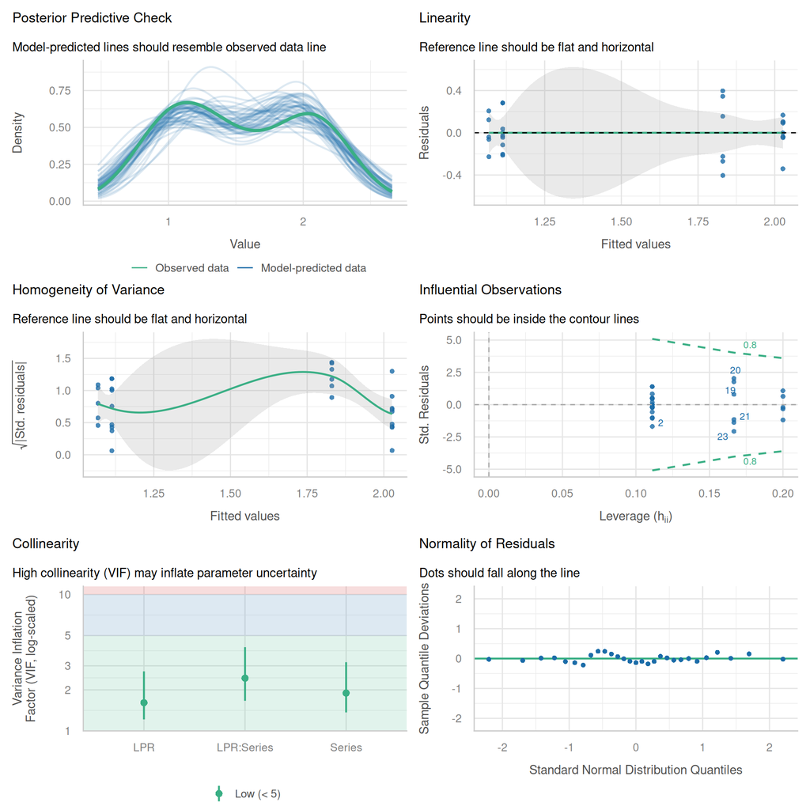

(a) Maximum amplitude

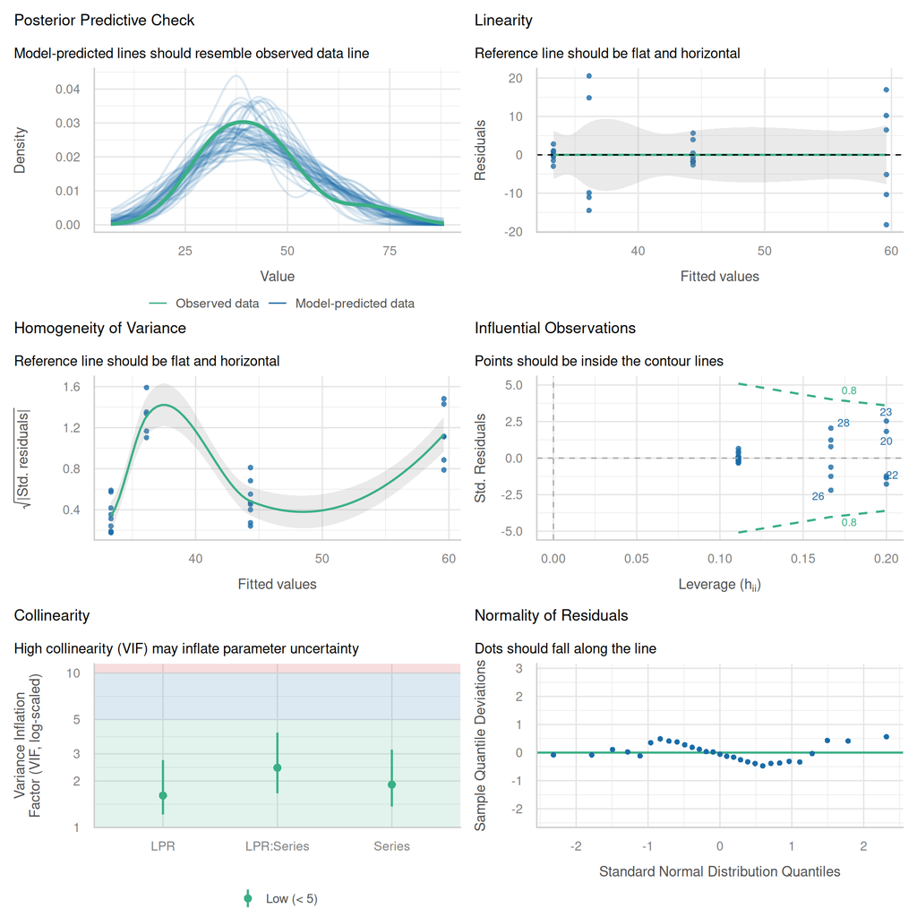

(b) Decay rate

```r
performance::check_model(model1_amp_lm, size_title=6)

performance::check_model(model1_k_lm, size_title=6)
```

While both models are acceptably linear with a normal distribution of residuals (Figure 2), there is a suggestion of heteroscedasticity, particularly for decay rate data (though the curve fit is suspect). To be cautious we therefore calculate heteroscedasticity-consistent standard errors, and recalculate effect sizes for the model parameters in Table 3.

```r
parameters::model_parameters(model1_amp_lm, vcov="HC3") |>
  kableExtra::kbl(digits=3) |>
  kableExtra::kable_styling(
    bootstrap_options = c("hover", "responsive")
    )
parameters::model_parameters(model1_k_lm, vcov="HC3") |>
  kableExtra::kbl(digits=3) |>
  kableExtra::kable_styling(
    bootstrap_options = c("hover", "responsive")
    )
```

Table 3: Revised parameters for each model, taking into account heteroscedasticity

(a) Maximum amplitude

| Parameter | Coefficient | SE | CI | CI_low | CI_high | t | df_error | p |
| --- | --- | --- | --- | --- | --- | --- | --- | --- |
| (Intercept) | 2.027 | 0.053 | 0.95 | 1.918 | 2.136 | 38.381 | 25 | 0.000 |
| LPRLPR10 | -0.914 | 0.083 | 0.95 | -1.085 | -0.742 | -10.993 | 25 | 0.000 |
| SeriesSeries 2 | -0.196 | 0.162 | 0.95 | -0.530 | 0.138 | -1.211 | 25 | 0.237 |
| LPRLPR10:SeriesSeries 2 | 0.151 | 0.194 | 0.95 | -0.248 | 0.551 | 0.779 | 25 | 0.443 |

(b) Decay rate

| Parameter | Coefficient | SE | CI | CI_low | CI_high | t | df_error | p |
| --- | --- | --- | --- | --- | --- | --- | --- | --- |
| (Intercept) | 44.332 | 1.024 | 0.95 | 42.223 | 46.442 | 43.285 | 25 | 0.000 |
| LPRLPR10 | -11.023 | 1.176 | 0.95 | -13.444 | -8.601 | -9.375 | 25 | 0.000 |
| SeriesSeries 2 | 15.269 | 6.086 | 0.95 | 2.735 | 27.804 | 2.509 | 25 | 0.019 |
| LPRLPR10:SeriesSeries 2 | -12.459 | 10.224 | 0.95 | -33.516 | 8.598 | -1.219 | 25 | 0.234 |

Taking into account heteroscedasticity, the model output (Table 3) now indicates that, for both maximum amplitude (-0.914nA, 95%CI[-1.08,-0.742]) and decay rate constant (-11.0/s, 95%CI[-13.4, -8.60]) there is a decrease with increasing `LPR`.

For maximum amplitude the model indicates no difference associated with `Series`, but there is a difference between `Series` for decay rate constant (15.3/s [2.74, 27.8]).

**Note**

Taking heteroscedasticity into account there is no strong evidence of interaction between terms for maximum amplitude or decay rate.

The contrasts of interest at each `LPR` are presented in Table 4.

```r
EMM <- emmeans::emmeans(model1_amp_lm, ~ Series | LPR, vcov=sandwich::vcovHC(model1_amp_lm))
confint(emmeans::contrast(EMM, "pairwise", adjust="sidak")) |>
  kableExtra::kbl() |>
  kableExtra::kable_styling(
    bootstrap_options = c("hover", "responsive")
  )
EMM <- emmeans::emmeans(model1_k_lm, ~ Series | LPR, vcov=sandwich::vcovHC(model1_k_lm))
confint(emmeans::contrast(EMM, "pairwise", adjust="sidak")) |>
  kableExtra::kbl() |>
  kableExtra::kable_styling(
    bootstrap_options = c("hover", "responsive")
  )
```

Table 4: Contrasts for `Series`, accounting for heteroscedasticity, with Sidak adjustments.

(a) Maximum amplitude

| contrast | LPR | estimate | SE | df | lower.CL | upper.CL |
| --- | --- | --- | --- | --- | --- | --- |
| Series 1 - Series 2 | LPR5 | 0.1963889 | 0.1622254 | 25 | -0.1377207 | 0.5304984 |
| Series 1 - Series 2 | LPR10 | 0.0452222 | 0.1063565 | 25 | -0.1738232 | 0.2642676 |

(b) Decay rate

| contrast | LPR | estimate | SE | df | lower.CL | upper.CL |
| --- | --- | --- | --- | --- | --- | --- |
| Series 1 - Series 2 | LPR5 | -15.269444 | 6.086282 | 25 | -27.80438 | -2.734511 |
| Series 1 - Series 2 | LPR10 | -2.810444 | 8.215022 | 25 | -19.72960 | 14.108711 |

The contrasts in Table 4 indicate that there is no difference in maximum amplitude associated with `Series` at either `LPR`. There is also no difference in decay rate between the two series at `LPR10`, but at `LPR5` an difference is seen (-15.3/s [-27.8,-2.73]).

## Figure

We present these relationships as in the manuscript, in Figure 3.

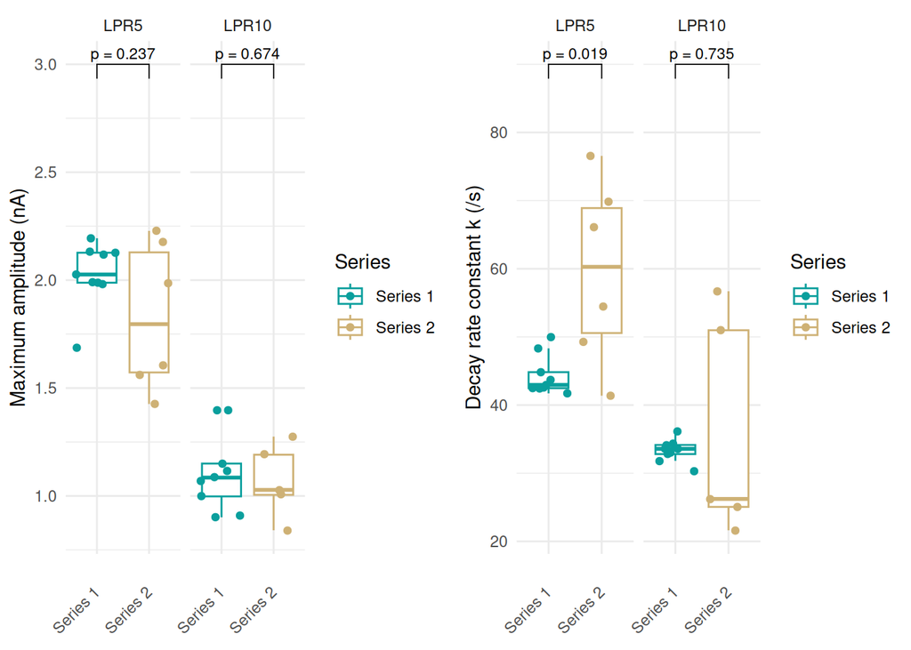

Figure 3: `WT` measurements across `LPR5` and `LPR10` for two batches/series, Sidak-adjusted *p*-values indicated

```r
# Get p-values, accounting for heteroscedasticity and multiple testing
# Also generate group1 and group2 columns
EMM_amp <- as.data.frame(pairs(emmeans::emmeans(model1_amp_lm, ~ Series | LPR,
                                                vcov=sandwich::vcovHC(model1_amp_lm)),
                               adjust="sidak")) |>
  tidyr::separate(contrast, into=c("group1", "group2"), sep=" - ") |>
  dplyr::mutate(y.position=3) |>
  rstatix::add_significance()
EMM_k <- as.data.frame(pairs(emmeans::emmeans(model1_k_lm, ~ Series | LPR,
                                              vcov=sandwich::vcovHC(model1_k_lm)),
                               adjust="sidak")) |>
  tidyr::separate(contrast, into=c("group1", "group2"), sep=" - ") |>
  dplyr::mutate(y.position=90) |>
  rstatix::add_significance()

p1_amp_annot <- p1_amp +
  ggpubr::stat_pvalue_manual(EMM_amp, label="p = {scales::pvalue(p.value)}", size=3)

p1_k_annot <- p1_k +
  ggpubr::stat_pvalue_manual(EMM_k, label="p = {scales::pvalue(p.value)}", size=3)

p_comp <- ggpubr::ggarrange(p1_amp_annot, p1_k_annot)
p_comp

# Write figures to file (commented out for webpage)
#ggplot2::ggsave("assets/images/fig00_WT_measurements_for_two_series_with_stats.pdf", p_comp)
#ggplot2::ggsave("assets/images/fig00_WT_measurements_for_two_series_with_stats.png", p_comp)
```

### Downloads

- Download as .pdf
- Download as .png